# Praca domowa 2

## Dane

Dane wykorzystane w Pracy domowej 2 dotyczą wyników egzaminów z 3 umiejętności: czytania, pisania i operacji matematycznych. Dodatkowo dostępne są podstawowe informacje o studentach i ich rodzicach. Opis wszystkich kolumn znajduje się również w pliku `README.md`.

| Zmienna | Opis |
| --- | --- |
| **gender** | płeć |
| **race.ethnicity** | pochodzenie etniczne |
| **parental.level.of.education** | wykształcenie rodziców |
| **lunch** | jaki obiad jedli uczniowie w dniu egzaminu |
| **test.preparation.course** | czy uczeń odbył kurs przygotowujący |
| **math.score** | wynik egzaminu z matematyki |
| **reading.score** | wynik egzaminu z czytania |
| **writing.score** | wynik egzaminu z pisania |

## Zadanie 1

Jak wyglądają rozkłady wyników uczniów z trzech przedmiotów (matematyka, czytanie, pisanie)?

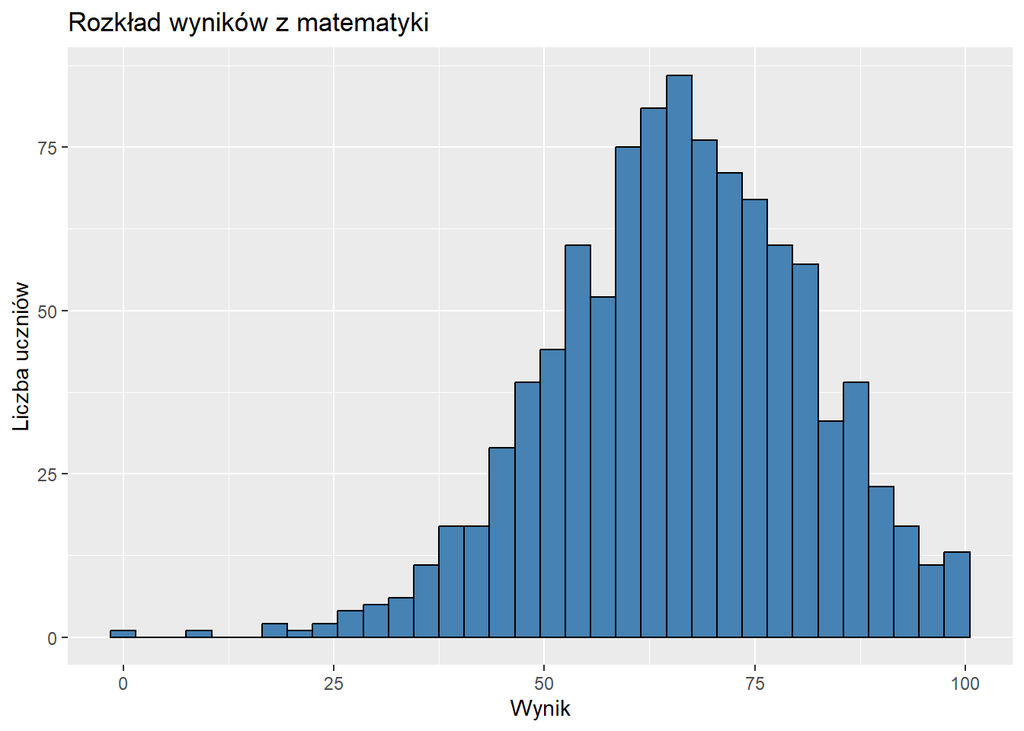

```r
# Tu umieść kod do wygenerowania odpowiedzi do zadania.


 ggplot(df,aes(x=math.score)) +
  geom_histogram(fill = "steelblue", color = "black",binwidth = 3)+
  labs(x="Wynik", y="Liczba uczniów", title="Rozkład wyników z matematyki")
```

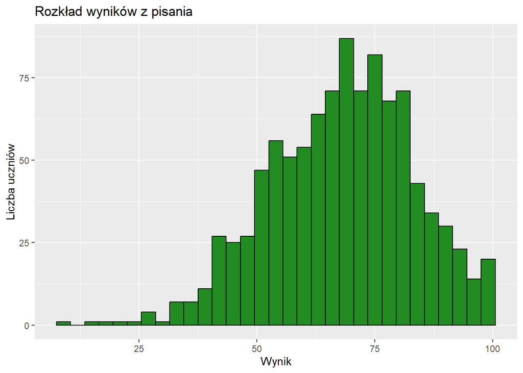

```r
ggplot(df,aes(x=writing.score))+
  geom_histogram(fill = "forestgreen", color = "black",binwidth = 3)+
  labs(x="Wynik", y="Liczba uczniów", title="Rozkład wyników z pisania")
```

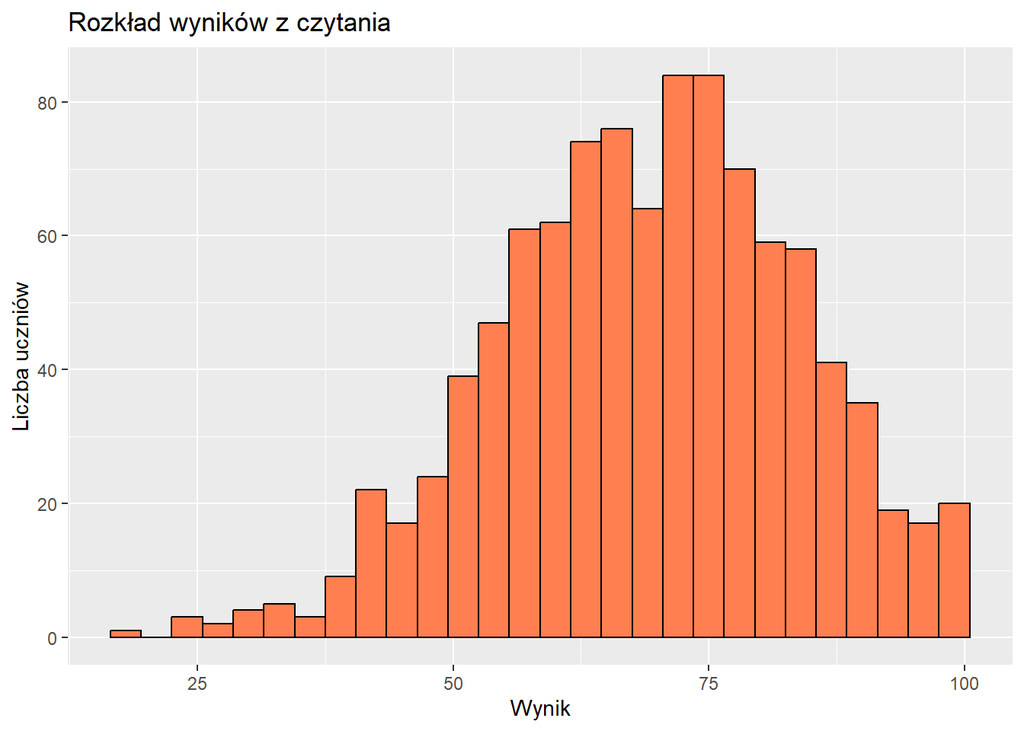

```r
ggplot(df,aes(x=reading.score))+
  geom_histogram(fill = "coral", color = "black",binwidth = 3)+
  labs(x="Wynik", y="Liczba uczniów", title="Rozkład wyników z czytania")
```

## Zadanie 2

Czy istnieje zauważalna różnica w wynikach między uczniami i uczennicami?

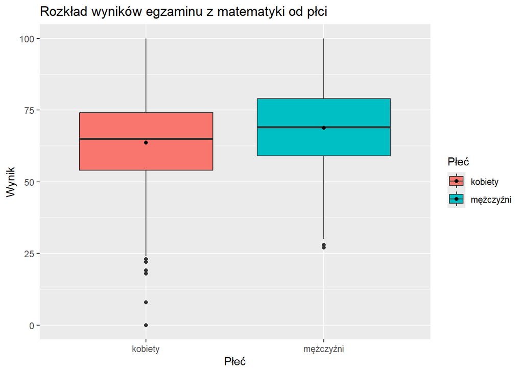

```r
# Tu umieść kod do wygenerowania odpowiedzi do zadania.

ggplot(df,aes(x=gender,y=math.score,fill=gender))+geom_boxplot()+
  stat_summary(fun = mean, geom = "point", color = "black")+
  labs(x="Płeć", y="Wynik", title="Rozkład wyników egzaminu z matematyki od płci")+
  scale_fill_discrete(name="Płeć")
```

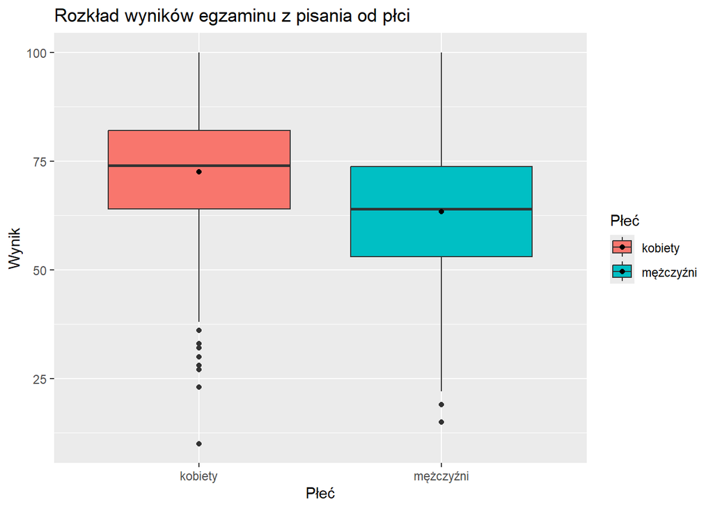

```r
ggplot(df,aes(x=gender,y=writing.score,fill=gender))+geom_boxplot()+
  stat_summary(fun = mean, geom = "point", color = "black")+
  labs(x="Płeć", y="Wynik", title="Rozkład wyników egzaminu z pisania od płci")+
  scale_fill_discrete(name="Płeć")
```

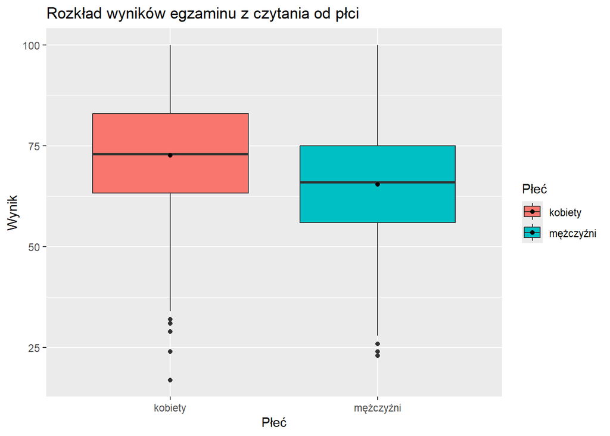

```r
ggplot(df,aes(x=gender,y=reading.score,fill=gender))+geom_boxplot()+
  stat_summary(fun = mean, geom = "point", color = "black")+
  labs(x="Płeć", y="Wynik", title="Rozkład wyników egzaminu z czytania od płci")+
  scale_fill_discrete(name="Płeć")
```

**Komentarz:** W wynikach uczniów i uczennic są zauważalne różnice. W przypadku egzaminu z matematyki, uczniowie uzyskują statystycznie wyniki lepsze niż uczennice, mediana wyników chłopców jest większa, podobnie jak średnia zaznaczona na wykresach kropką. Mniej jest też w przypadku wyników chłopców wartości skrajnie niskich. Jeśli chodzi o egzaminy z czytania i pisania sytuacja jest odwrotna. Uczennice statystycznie uzyskują wyniki lepsze niż uczniowie, a różnica jest nawet bardziej widoczna na korzyść dziewcząt niż była na korzyść chłopców w przypadku matematyki. Mediana i średnia wyników dziewcząt w przypadku pisania i czytania jest wyższa, lecz dalej jest więcej wartości skrajnie niskich niż u chłopców.

## Zadanie 3

Czy uczniowie, którzy ukończyli kurs przygotowawczy, osiągają lepsze wyniki niż pozostali?

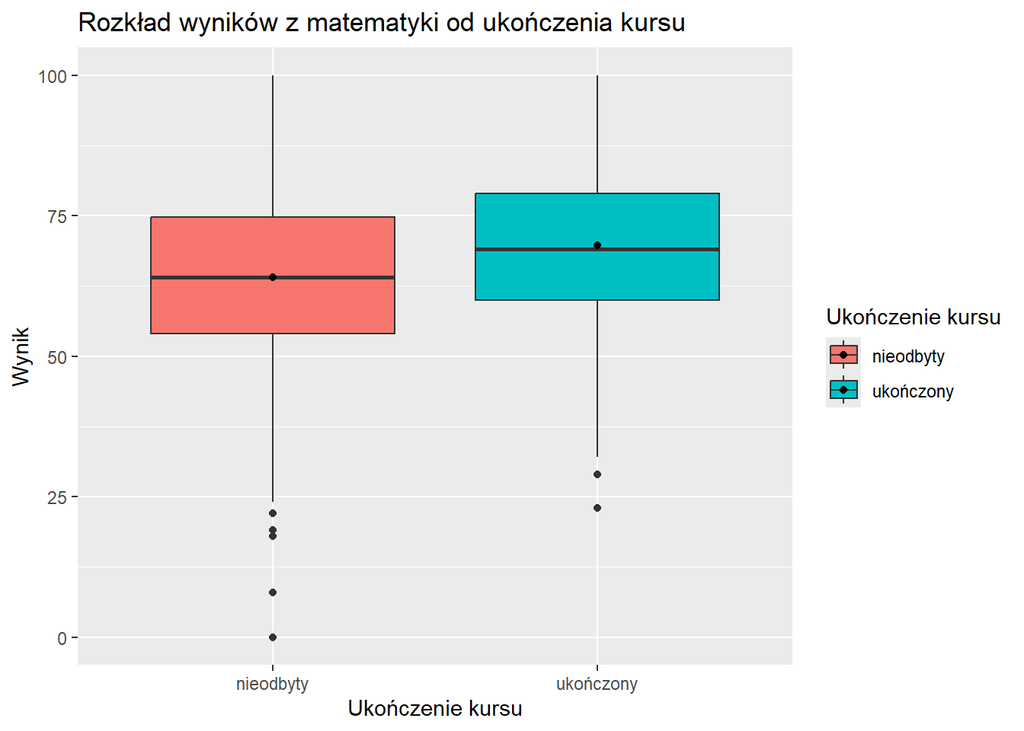

```r
# Tu umieść kod do wygenerowania odpowiedzi do zadania.
ggplot(df,aes(x=test.preparation.course,y=math.score,fill=test.preparation.course))+
  geom_boxplot()+
  stat_summary(fun = mean, geom = "point", color = "black")+
  labs(x="Ukończenie kursu", y="Wynik", title="Rozkład wyników z matematyki od ukończenia kursu")+
  scale_fill_discrete(name="Ukończenie kursu")
```

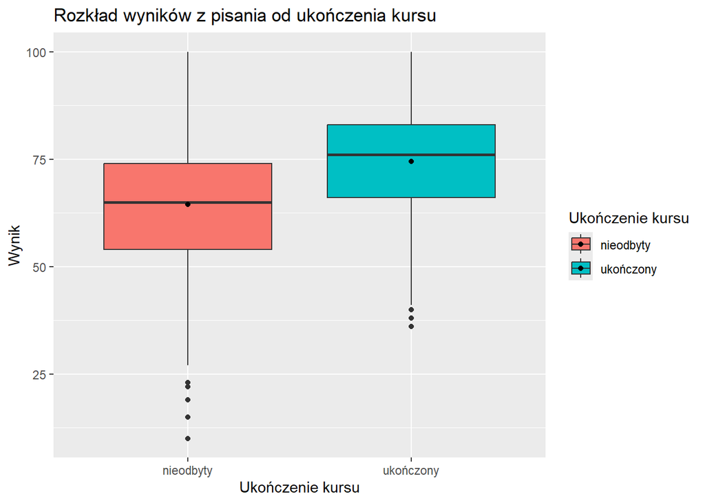

```r
ggplot(df,aes(x=test.preparation.course,y=writing.score,fill=test.preparation.course))+
  geom_boxplot()+
  stat_summary(fun = mean, geom = "point", color = "black")+
  labs(x="Ukończenie kursu", y="Wynik", title="Rozkład wyników z pisania od ukończenia kursu")+
  scale_fill_discrete(name="Ukończenie kursu")
```

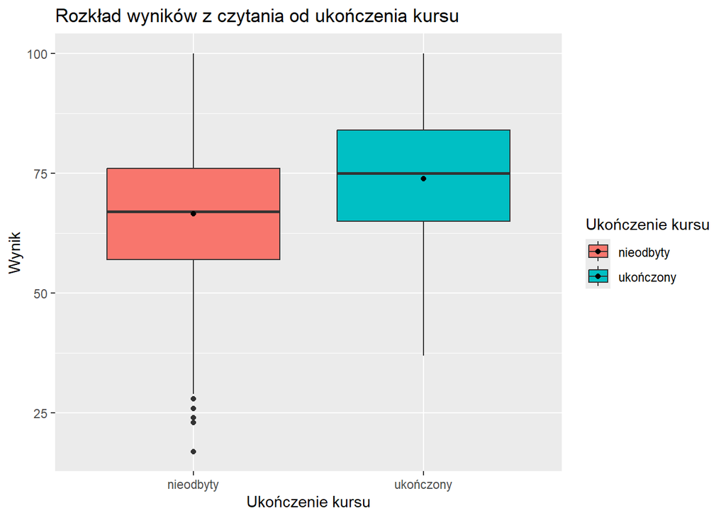

```r
ggplot(df,aes(x=test.preparation.course,y=reading.score,fill=test.preparation.course))+
  geom_boxplot()+
  stat_summary(fun = mean, geom = "point", color = "black")+
  labs(x="Ukończenie kursu", y="Wynik", title="Rozkład wyników z czytania od ukończenia kursu")+
  scale_fill_discrete(name="Ukończenie kursu")
```

**Komentarz:** W przypadku wszystkich trzech egzaminów uczniowie, którzy ukończyli kurs przygotowawczy uzyskują wyższe wyniki niż uczniowie, którzy kursu nie odbyli. Różnice są najbardziej widoczne w przypadku egzaminu z czytania i pisania, w grupie uczniów bez ukończonego kursu jest też zdecydowanie więcej wyników skrajnie niskich.

## Zadanie 4

Jaki jest związek między poziomem wykształcenia rodziców a średnimi wynikami uczniów?

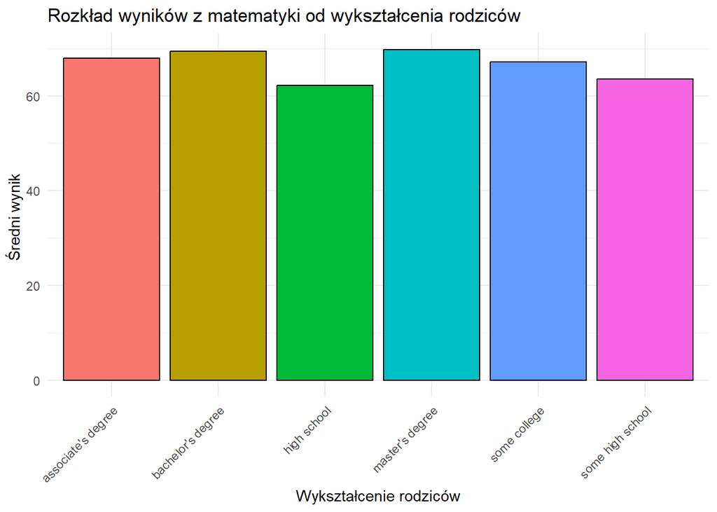

```r
x4<-df %>% select(parental.level.of.education,math.score,reading.score,writing.score) %>%
  group_by(parental.level.of.education) %>%
  summarise(srednia_mat=round(mean(math.score),2),
            srednia_czyt=round(mean(reading.score),2),
            srednia_pis=round(mean(writing.score),2))

ggplot(x4,aes(x=parental.level.of.education,y=srednia_mat,fill=parental.level.of.education)) + geom_col(color="black")+
  theme_minimal()+
   theme(axis.text.x = element_text(angle = 45, hjust = 1))+ theme(legend.position = "none")+
  labs(x="Wykształcenie rodziców", y="Średni wynik ", title="Rozkład wyników z matematyki od wykształcenia rodziców")
```

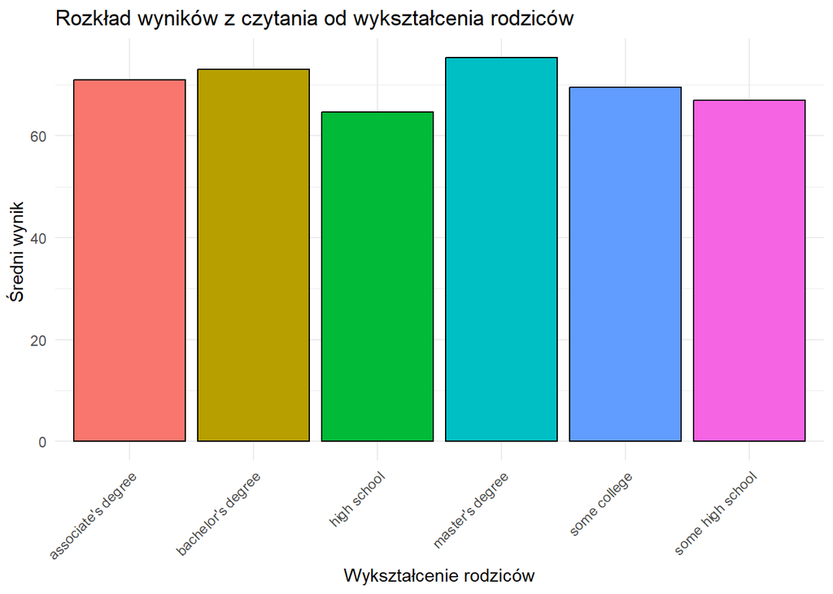

```r
ggplot(x4,aes(x=parental.level.of.education,y=srednia_czyt,fill=parental.level.of.education)) + geom_col(color="black")+
  theme_minimal()+
   theme(axis.text.x = element_text(angle = 45, hjust = 1))+ theme(legend.position = "none")+
  labs(x="Wykształcenie rodziców", y="Średni wynik ", title="Rozkład wyników z czytania od wykształcenia rodziców")
```

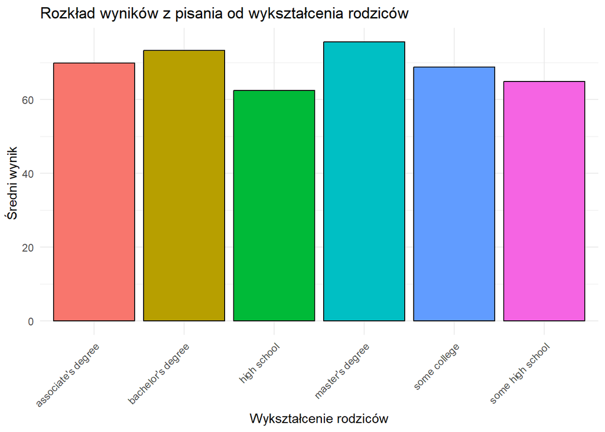

```r
ggplot(x4,aes(x=parental.level.of.education,y=srednia_pis,fill=parental.level.of.education)) + geom_col(color="black")+theme_minimal()+
   theme(axis.text.x = element_text(angle = 45, hjust = 1))+ theme(legend.position = "none")+
  labs(x="Wykształcenie rodziców", y="Średni wynik ", title="Rozkład wyników z pisania od wykształcenia rodziców")
```

## Zadanie 5

Czy płeć i wykształcenie rodzica wpływa na wynik z matematyki?

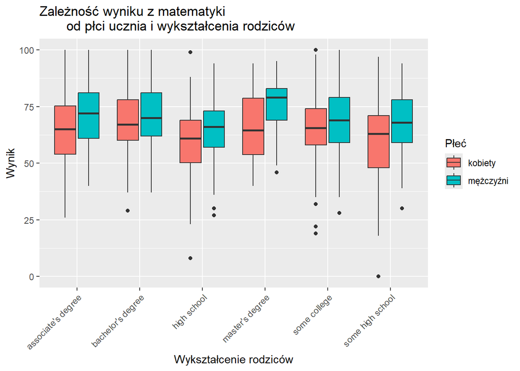

```r
ggplot(df,aes(x=parental.level.of.education,y=math.score,fill=gender))+
  geom_boxplot()+
   theme(axis.text.x = element_text(angle = 45, hjust = 1))+
  labs(x="Wykształcenie rodziców",y="Wynik",title="Zależność wyniku z matematyki
       od płci ucznia i wykształcenia rodziców")+
  scale_fill_discrete(name="Płeć")
```

**Komentarz:** Według danych płeć i wykształcenie rodziców zdecydowanie wpływają na wynik z matematyki. W przypadku każdego stopnia wykształcenia rodziców chłopcy uzyskują wyższe wyniki niż dziewczynki, mediana ich wyników jest w każdym przypadku zawuażalnie wyższa. Największa różnica jest widoczna w przypadku wykształcenia wyższego rodziców, gdzie chłopcy uzysują średnio dużo lepsze wyniki niż dziewczynki.Jednakże mediana wyników dziewczynek jest całkiem zbliżona niezależnie od stopnia wykształcenia rodziców i wcale dziewczynki, których rodzice mają najwyższe wykształcenie nie uzyskują najwyższych wyników, gdzie taki trend jest widoczny w przypadku chłopców.

## Zadanie 6

Czy istnieje zależność między wynikami z matematyki a wynikami z czytania lub pisania?

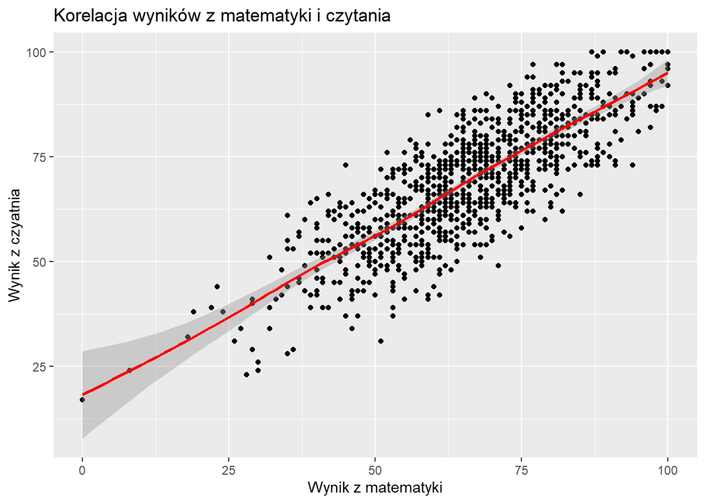

```r
ggplot(df,aes(x=math.score,y=reading.score))+geom_point(color="black")+
geom_smooth(color="red")+labs(x="Wynik z matematyki",y='Wynik z czyatnia',
title="Korelacja wyników z matematyki i czytania")
```

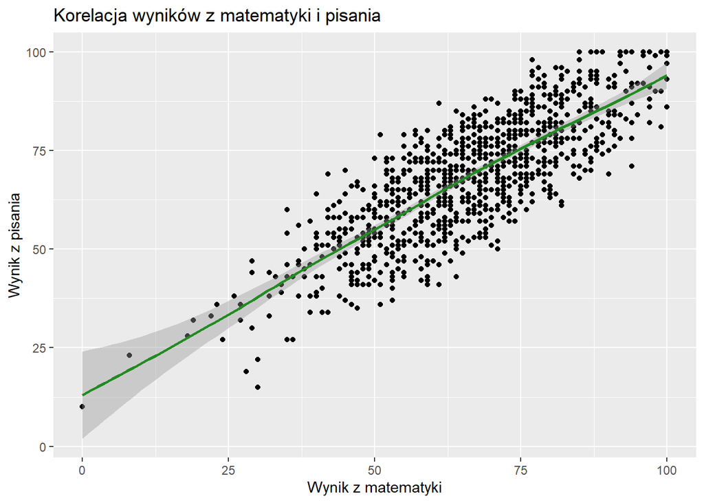

```r
ggplot(df,aes(x=math.score,y=writing.score))+geom_point(color="black")+
  geom_smooth(color="forestgreen")+labs(x="Wynik z matematyki",y='Wynik z pisania',
  title="Korelacja wyników z matematyki i pisania")
```

```r
#Współczynnik korelacji wyniku z matematyki i czytania
cor(df$math.score,df$reading.score)
```

```
## [1] 0.8175797
```

```r
#Współczynnik korelacji wyniku z matematyki i pisania
cor(df$math.score,df$writing.score)
```

```
## [1] 0.802642
```

**Komentarz:** Jak pokazują wykresy korelacji zdecydowanie im wyższy wynik egzaminu z matematyki, tym wyższy wynik egzaminu z pisania/czytania. Zależność dodatnio liniowa między wynikiem z matematyki a pozostałymi wynikami jest silna, w obu przypadkach współczynnik korelacji Persona wynosi około 0.8 .